Load libraries and data

```r
library(phytools)
library(geiger)
library(picante)
library(phylocurve)
library(geomorph)
library(tidyverse)

scent <- read.csv("assets/code/scent/compounds.csv") # Import Scent GCMS floral scent data
tree <-read.nexus("assets/code/scent/THALICTRUM86.tre") # Read in pre-cooked Maximum A Posterior Phylogeny (MAP)
EAG <- read.csv("assets/code/scent/EAGresponses.csv") # Import EAG data
```

## Test for Phylogenetic Signal

We were intrested in testing whether closely related species exhibitd similar amounts of volitale compounds. We can do this by calculating Blombergs K a measure of phylogenetic signal. Generally you can interpret K as the following

K < 1 closely related species are less similar than expected under brownian motion. K = 1 closely related species are as similar/different as expected under brownian motion K >1 closely related species are more similar than expected under brownian motion.

This is traditionally performed on single trait, however biologist are often intrested in how complex traits composed of many different variable evolve. Because our GCMS data is multivariate (~50 compounds), we can calculate Blombergs K for each individaul compound as well as the entire datset as a whole.

Prune MAP phylogeny to species with GCMS data

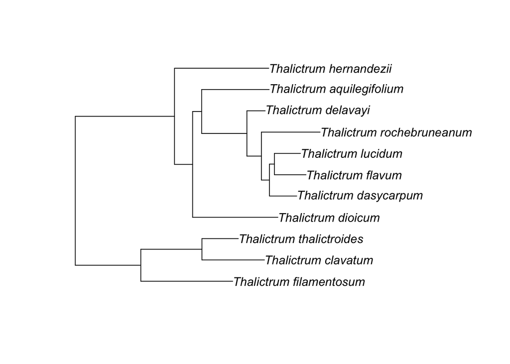

```r
keepSpecies <- unique(as.character(scent$Species_Name_Full))
trimedTree <- drop.tip(tree,tree$tip.label[-match(keepSpecies, tree$tip.label)])
plot(trimedTree)
```

Extract scent emission data take the averge of biological replicates and wrangle the data into the proper formate for the downstream functons.

```r
#1)
scentCompounds <- scent[,9:63] # extract only scent data +  mass*time column
scentCompounds$Species_Name_Full <- scent$Species_Name_Full # Add species names back in

#2)  Average Scent Data Accross Biological Replicates
avgScentCompounds <- aggregate( scentCompounds,
                                by=list(scentCompounds$Species_Name_Full),
                                FUN = mean,
                                na.rm=TRUE)
#3)
avgScentCompounds$Species_Name_Full <- NULL
row.names(avgScentCompounds) <- avgScentCompounds$Group.1
avgScentCompounds$Group.1 <- NULL
avgScentCompounds <- as.matrix(avgScentCompounds)
avgScentCompounds[,1:5]
```

[output not shown]

#### Bloombergs K

Data is formated, we can now calculate Blombergs K for each compound individually.

```r
multiPhylosignal(avgScentCompounds, tree)
```

```
##                                                          K
## Mass.time                                        0.7385669
## Limonene                                         0.3340407
## X3.Hexen.1.ol...Z..                              0.2492910
## X1.Hexanol                                       0.3883188
## beta.Pinene                                      0.2681185
## X3.Hexen.1.ol..acetate...Z..                     0.2486036
## trans.beta.Ocimene                               0.3702101
## Caryophyllene                                    0.3215032
## Humulene                                         0.3890120
## alpha.Farnesene                                  0.3560754
## X3.Carene                                        0.3508240
## Methyl.Benzoate                                  0.3590712
## X.E..beta.Famesene                               0.2374881
## Germacrene.D                                     0.2434557
## Pentadecane                                      0.7406907
## Heptadecane                                      0.5174426
## alpha.Pinene                                     0.2902098
## Camphene                                         0.4374292
## beta.Myrcene                                     0.3631219
## Tridecane                                        0.7857405
## Tetradecanal                                     0.7872098
## Benzaldehyde                                     0.4779120
## Eucalyptol                                       0.6550058
## X1.Dodecene                                      0.6366995
## Tetradecanoic.acid..ethyl.ester                  0.6550058
## X1.Octanol                                       0.4106495
## Octanoic.acid..ethyl.ester                       0.2619039
## Dodecane                                         0.5891558
## Tetradecane                                      0.6939679
## Hexadecane                                       0.8954568
## Hexadecanoic.acid..ethyl.ester                   0.6550058
## Anisole                                          0.2576813
## Acetophenone                                     0.4970347
## Benzyl.Benzoate                                  0.5489103
## Butanedioic.acid..diethyl.ester                  0.4970347
## Benzeneacetic.acid..ethyl.ester                  0.4970347
## Undecane                                         0.7975390
## Decanal                                          0.7891057
## Dodecanal                                        0.7981688
```

[output cut: 225 more lines]

```
## X2.Hexenal                                            1.3250178
## Decane                                                1.3757510
## Butanoic.acid..3.hexenyl.ester...Z..                  1.3637025
## Styrene                                               1.0193620
## X2.6.Octadien.1.ol..3.7.dimethyl....Z..               1.0521298
## X2.6.Octadienal..3.7.dimethyl....Z..                  1.0577719
## X2.6.Octadien.1.ol..3.7.dimethyl....E..               1.0011635
## X2.6.Octadienal..3.7.dimethyl.                        1.0530120
## X2.Propen.1.ol..3.phenyl.                             1.0650846
## X6.Octen.1.ol..3.7.dimethyl...acetate                 1.1219431
## X2.6.Octadien.1.ol..3.7.dimethyl...acetate...Z..      0.4603887
## Geranyl.acetate                                       0.1954711
## gamma.Terpinene                                       1.3355970
## Decanoic.acid..ethyl.ester                            1.3136440
## beta.Phellandrene                                     1.2812382
```

We can now calculate Blombergs K with the entire dataset as a whole. I thikn multivariate comparative methods are still in their infense and a lot of work is being done figure out how to deal with multivarite data. There are two libraries that have this implementation, Phylocurve and Geomorph.

#### PhyloCurve Implementation

```
##
## Bootstrapping under null model.
```

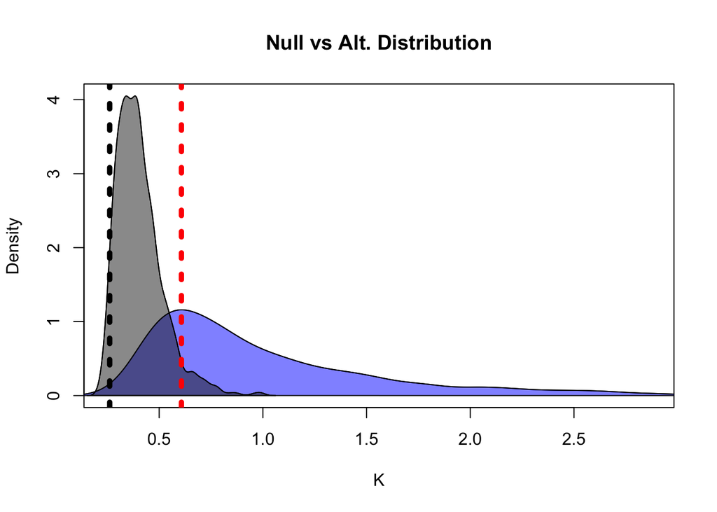

```
##
## **********Simulation results**********
## Test statistic (K)      0.2612838
## Critical test statistic 0.6072138
## Estimated Power         0.7240000
##
## P-value: 0.96
```

```r
model <- evo.model(trimedTree, avgScentCompounds)
K.mult(model, nsim = 1000, plot = TRUE)
```

Figure Interpretation: Black density plot is null distribution of K values from 1000 simulations of Brownian motion under a star phylogeny. Blue is a distribution of K values from 1000 simulations on the true phylogeny. Black dotted line is observe K value from multiveriate Bloomberg’s K on observed data. This value falls well within the null distribution of simulation, indicating that there is no phylogenetic signal.

#### Geomorph Implimentation

```r
zzz<-physignal(avgScentCompounds,trimedTree)
```

## Test for Phylogenetic Signal

In addition to the VOC compounds we had an additional data source.

Prune Tree down to 8 species with EAG data

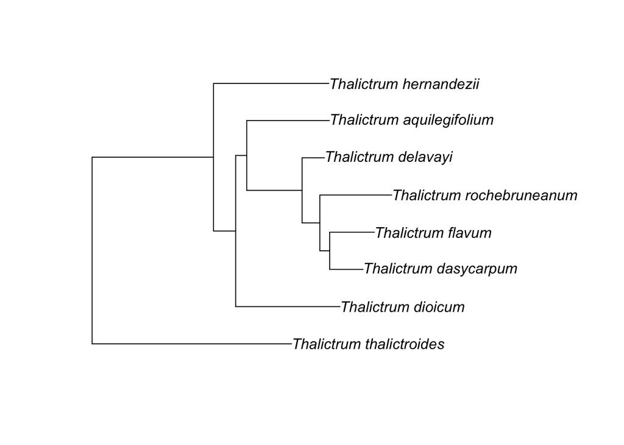

```r
keepSpecies <- EAG$Species_Name_Full
trimedTree<-drop.tip(tree,tree$tip.label[-match(keepSpecies, tree$tip.label)])
plot(trimedTree)
```

## Data Wrangle EAG Response

```r
continuousResponse <- as.matrix(data.frame(row.names = EAG$Species_Name_Full,
                                 EAG$EAG))[,1]

sigResponses <- as.matrix(data.frame(row.names = EAG$Species_Name_Full,
                                    EAG$EAG_Sig))[,1]
```

```r
EAGBloombergsK <- as.matrix(continuousResponse)
multiPhylosignal(EAGBloombergsK, tree)
```

```
##           K PIC.variance.obs PIC.variance.rnd.mean PIC.variance.P
## 1 0.2366938          12.0132              6.715752          0.999
##   PIC.variance.Z
## 1       2.900658
```

# Ancestrl State Reconstruction

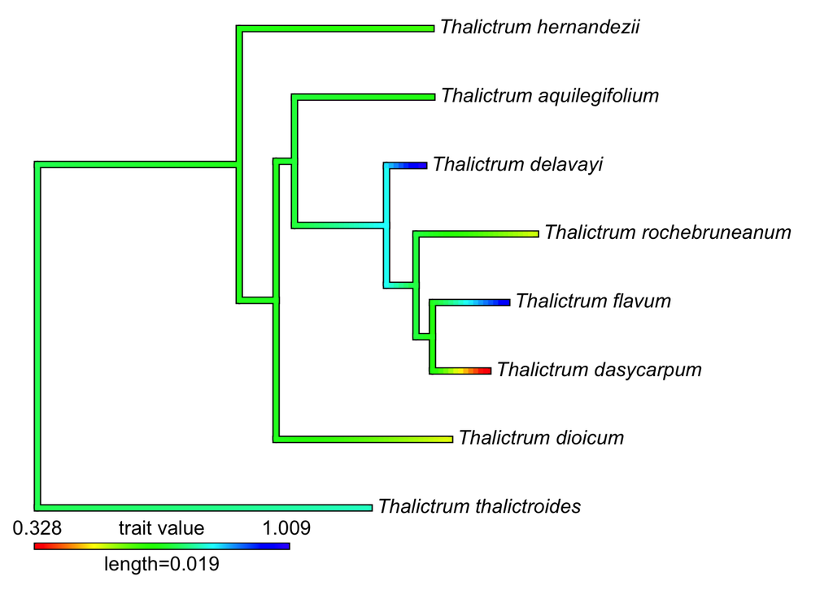

```r
g <- contMap(trimedTree, continuousResponse, plot = TRUE, type="phylogram")
```

```r
# Testing between ER and ARD
results.anc <- data.frame( model=c("ER","ARD"),
                           lnL=numeric(2),
                           AICc=numeric(2),
                           params=numeric(2))

ER_fit <- fitDiscrete(trimedTree, sigResponses, model="ER")
results.anc[1,-1]<- c(lnL=ER_fit$opt$lnL,AICc=ER_fit$opt$aicc,ER_fit$opt$k)
ARD_fit <- fitDiscrete(trimedTree, sigResponses, model="ARD")
results.anc[2,-1]<- c(lnL=ARD_fit$opt$lnL,AICc=ARD_fit$opt$aicc,ARD_fit$opt$k)
results.anc <- results.anc[order(results.anc$AICc),]
results.anc
```

```
##   model       lnL     AICc params
## 1    ER -5.545177 13.75702      1
## 2   ARD -5.545177 17.49035      2
```

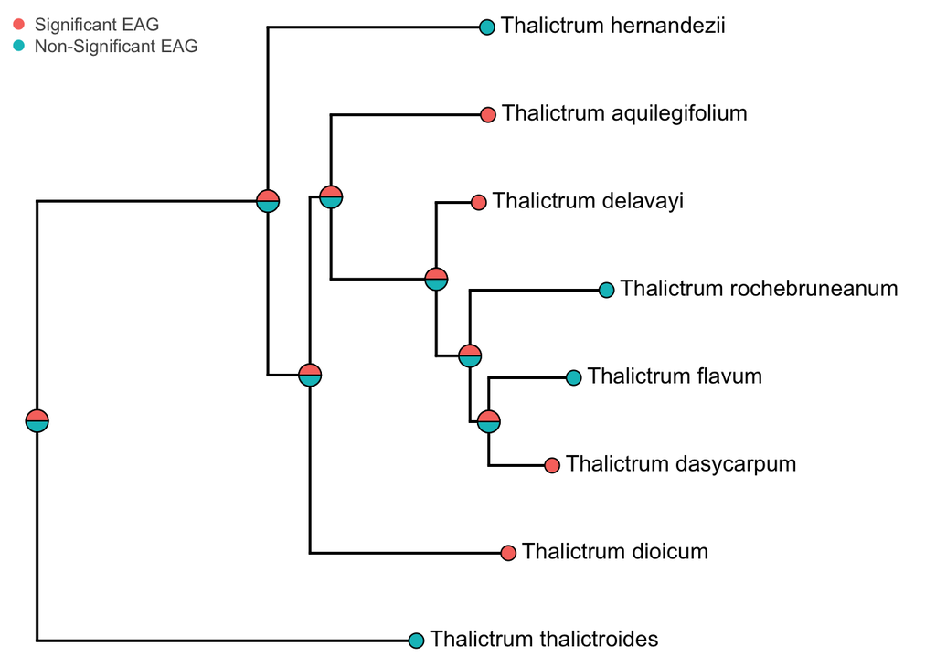

```r
# Plotting Joint Marginal Estimation of ER
z <- as.factor(sigResponses)

ERreconstruction <- ace(z, trimedTree, type="discrete", model="ER")

plotTree(trimedTree, setEnv = TRUE, offset = 0.5)
tiplabels(pie = to.matrix(z, sort(unique(z))),
          piecol = c("#F8766D", "#00BFC4"),
          cex = 0.4)
nodelabels( node=1:trimedTree$Nnode+Ntip(trimedTree),
            pie = ERreconstruction$lik.anc,
            cex=0.6,
            piecol = c("#F8766D", "#00BFC4"))

nodelabels(
            pie = ERreconstruction$lik.anc,
            piecol = c("#F8766D", "#00BFC4"),
            cex = 0.6)


legend("topleft",
       legend=c("Significant EAG", "Non-Significant EAG"),
       pch=20,
       col=c("#F8766D", "#00BFC4"),
       bty="n",
       text.col="gray32",
       cex=0.8,
       pt.cex=1.5)
```

```r
set.seed(1234)
cols <- setNames(c("#1b9e77","#7570b3","#d95f02"), sort(unique(sigResponses)))
chartrees <- make.simmap(trimedTree, sigResponses, model='ER', nsim = 200)
```

```
## make.simmap is sampling character histories conditioned on the transition matrix
##
## Q =
##           1         2
## 1 -1057.981  1057.981
## 2  1057.981 -1057.981
## (estimated using likelihood);
## and (mean) root node prior probabilities
## pi =
##   1   2
## 0.5 0.5
```

```r
(res_simmap <- describe.simmap(chartrees, plot = FALSE))
```

```
## 200 trees with a mapped discrete character with states:
##  1, 2
##
## trees have 122.46 changes between states on average
##
## changes are of the following types:
##        1,2   2,1
## x->y 61.18 61.28
##
## mean total time spent in each state is:
##               1         2     total
## raw  0.05728896 0.0570632 0.1143522
## prop 0.50098713 0.4990129 1.0000000
```

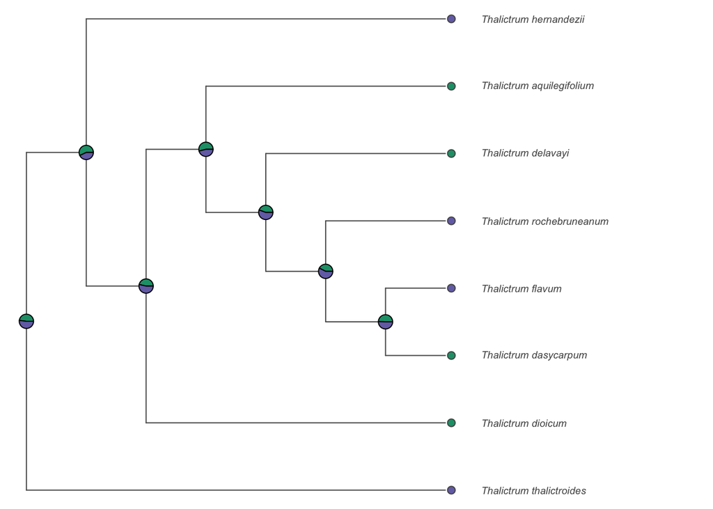

```r
plot( trimedTree,type="p",
      FALSE,label.offset=0.6,
      cex=0.6,
      no.margin=TRUE,
       edge.color="gray32",
      tip.color="gray32")

tiplabels( pch=21,bg=cols[as.numeric(sigResponses)],
           col="gray32",
           cex=1,
           adj=0.6)
nodelabels( pie=res_simmap$ace,
            piecol=cols,
            cex=0.5,
            col="gray32")
```

```r
#legend("bottomleft",
#       legend=levels(sigResponses),
#       pch=20,
#       col="gray32",
#       bty="n",
#       text.col="gray32",
#       cex=0.8,
#       pt.cex=1.5)


#plotSimmap(chartrees, cols, pts = FALSE, lwd = 3, fsize=0.6)
#add.simmap.legend(colors = cols, vertical = FALSE, prompt = FALSE, x = 0, y = 1)
```

References Jones et al. 2015